# Exam 1 Practice

```r
fit <- lm(y~x1*x2 + x3, data = Data)
summary(fit)
```

```
##
## Call:
## lm(formula = y ~ x1 * x2 + x3, data = Data)
##
## Residuals:
##    Min     1Q Median     3Q    Max
## -4.288 -1.179 -0.221  1.231  3.924
##
## Coefficients:
##              Estimate Std. Error t value Pr(>|t|)
## (Intercept)  0.758088   0.276696   2.740  0.00736 **
## x1          -0.235987   0.190945  -1.236  0.21958
## x2          -1.111394   0.180166  -6.169 1.72e-08 ***
## x3b          0.007804   0.407237   0.019  0.98475
## x3c         -0.210479   0.455034  -0.463  0.64475
## x1:x2       -0.380193   0.192521  -1.975  0.05122 .
## ---
## Signif. codes:  0 '***' 0.001 '**' 0.01 '*' 0.05 '.' 0.1 ' ' 1
##
## Residual standard error: 1.758 on 94 degrees of freedom
## Multiple R-squared:  0.3073, Adjusted R-squared:  0.2705
## F-statistic: 8.342 on 5 and 94 DF,  p-value: 1.471e-06
```

3. Calculate residuals by hand (i.e., do not use the resid() function).

y= b0 + b1 * x1 + b2 * x2 + b3 * x3b + b4 * x3c + b5 x1 * x2

```r
#since we have a categorical we have to set up the ifelse
Data$b <- ifelse(Data$x3 == 'b', 1, 0)
Data$c <- ifelse(Data$x3 == 'c', 1, 0)
# then we store our coefficients so we can index them
b<-coef(fit)
print(b)
```

```
##  (Intercept)           x1           x2          x3b          x3c        x1:x2
##  0.758087590 -0.235986737 -1.111393659  0.007803951 -0.210478885 -0.380192677
```

```r
#predicting the new values
predicting<-b[1]+b[2]*Data$x1+b[3]*Data$x2+b[4]*Data$b+b[5]*Data$c+b[6]*Data$x1*Data$x2
res<-Data$y-predicting
summary(res)
```

```
##    Min. 1st Qu.  Median    Mean 3rd Qu.    Max.
##  -4.288  -1.180  -0.221   0.000   1.231   3.924
```

4. Interpret the effect of variable x2 when x1 = -1

y= b0 + b1 * x1 + b2 * x2 + b3 * x3b + b4 * x3c + b5 x1 * x2

We just want to look at the rate of change of x2 so ignore the other instances of x1

b2 * x2 + b5 x1 * x2

x2(b2+b5*-1)

- remember that the coeff will be one higher than the b number shown *

```r
rate<-1*(b[3]-b[6])
print(rate)
```

```
##        x2
## -0.731201
```

5. Interpret the effect of variable x2 when x1 = 1

```r
rate<-1*(b[3]+b[6])
print(rate)
```

```
##        x2
## -1.491586
```

6. Plot predicted y against the observed range of x2. Assume level ‘a’ of your categorical variable and fix x1 at its mean.

The equation y= b0 + b1 * x1 + b2 * x2 + b3 * x3b + b4 * x3c + b5 x1 * x2 So we assume level ‘a’ of your categorical variable so x3b & x3c go away

y= b0 + b1 * x1 + b2 * x2 + b5 x1 * x2

Find the mean of x1

```r
x1mean<-mean(Data$x1)
```

plug it in to get expected

```r
ExpectedY<- b[1] + b[2] * x1mean + b[3] * Data$x2 + b[6] * x1mean * Data$x2
```

plot

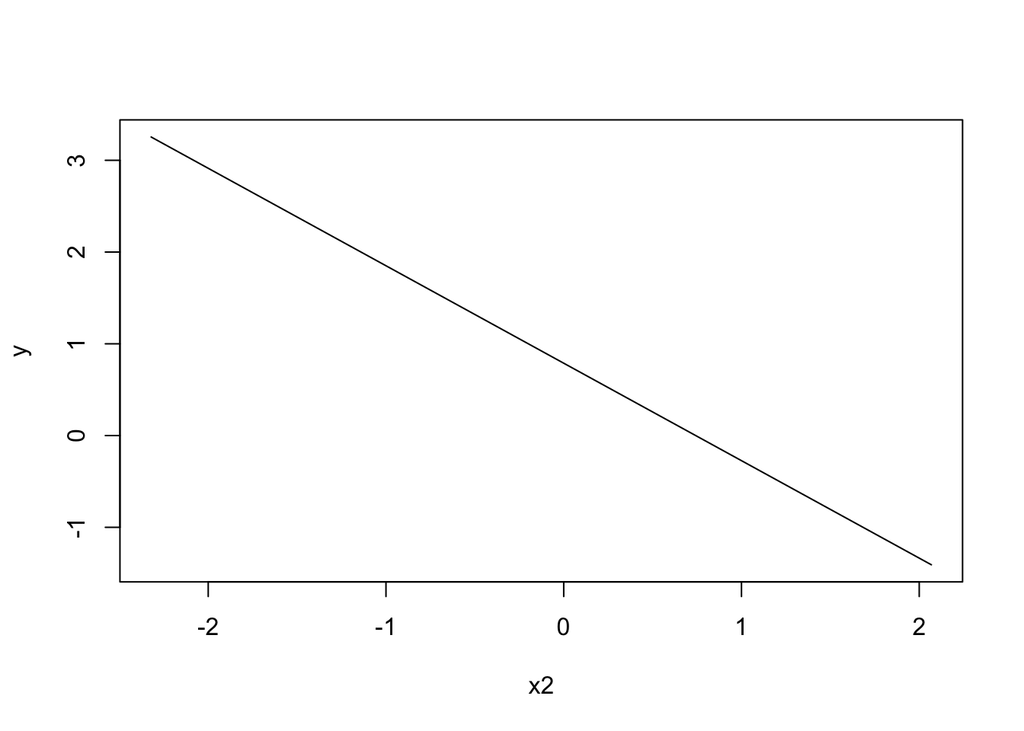

```r
plot(x = Data$x2, y = ExpectedY, type = 'l', xlab = 'x2', ylab = 'y')
```

7. Interpret the effect of variable x3 *** Your just looking for the coefficients***

x3b = 0.007803951 x3c = -0.210478885

When all else is held constant

```r
print(b)
```

```
##  (Intercept)           x1           x2          x3b          x3c        x1:x2
##  0.758087590 -0.235986737 -1.111393659  0.007803951 -0.210478885 -0.380192677
```

8. Describe how R codes the categorical variable x3. Demonstrate by reporting the first 5 values of variables derived from x3

R create k-1 dummy variables. A is set aside as a reference. When x3 is A X3b & x3c are zero. A dummy variable is created for when x3 equals b and when x3 equals c. When x3 is b, x3b is 1 x3c is zero. When x3 is c, x3b is 0 and x3c is 1.

```r
cbind(Data$x3[1:5],
  ifelse(Data$x3 == 'b', 1, 0)[1:5],
  ifelse(Data$x3 == 'c', 1, 0)[1:5])
```

```
##      [,1] [,2] [,3]
## [1,]    3    0    1
## [2,]    2    1    0
## [3,]    1    0    0
## [4,]    1    0    0
## [5,]    1    0    0
```

9. Derive the test statistic and p-value associated with variable x2. What is the null hypothesis assumed by the lm() function? Do we reject or fail to reject this null hypothesis?

the coefficient/std.error

```r
ts <- coef(fit)[3] / summary(fit)[['coefficients']][3, 2]
print(ts)
```

```
##        x2
## -6.168704
```

```r
summary(fit)
```

```
##
## Call:
## lm(formula = y ~ x1 * x2 + x3, data = Data)
##
## Residuals:
##    Min     1Q Median     3Q    Max
## -4.288 -1.179 -0.221  1.231  3.924
##
## Coefficients:
##              Estimate Std. Error t value Pr(>|t|)
## (Intercept)  0.758088   0.276696   2.740  0.00736 **
## x1          -0.235987   0.190945  -1.236  0.21958
## x2          -1.111394   0.180166  -6.169 1.72e-08 ***
## x3b          0.007804   0.407237   0.019  0.98475
## x3c         -0.210479   0.455034  -0.463  0.64475
## x1:x2       -0.380193   0.192521  -1.975  0.05122 .
## ---
## Signif. codes:  0 '***' 0.001 '**' 0.01 '*' 0.05 '.' 0.1 ' ' 1
##
## Residual standard error: 1.758 on 94 degrees of freedom
## Multiple R-squared:  0.3073, Adjusted R-squared:  0.2705
## F-statistic: 8.342 on 5 and 94 DF,  p-value: 1.471e-06
```

```r
#df = n − k degrees of freedom, where k is the number of regression coefficients in your linear model.
dfs<-100 - 6
pt(ts, df = dfs ) * 2
```

```
##           x2
## 1.720716e-08
```

```r
summary(fit)[['coefficients']][3, 4]
```

```
## [1] 1.720716e-08
```

#We reject the null hypothesis because the p-value is smaller than any reasonable α.